# Procedurally generated worlds using Pandas and Numpy

I'm a big fan of rouge-like games and RPGs. I'm also a big fan of data science tools for Python. This is my attempt to have it all.

```python
import pandas as pd
import numpy as np

import altair as alt

#importing local libraries for drawings (because they clutter)
#   They should still be available within the git repo but it's pretty much template stuff from altair
import drawMaps as draw
```

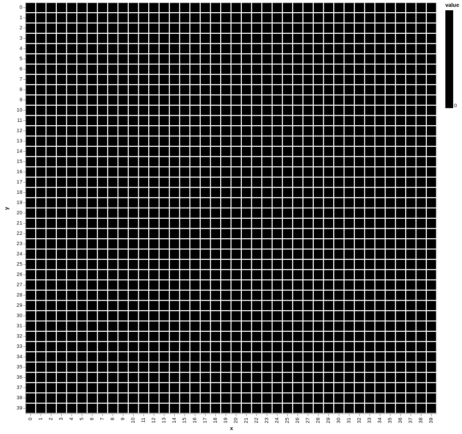

```python
grid = [40,40] #starting size of the grid (world size)

#land Specifications
drop_iter = 10 #number of times a terain item will be dropped
spread_iter = 60 #number of times a dropped item will spread out (affects land mass size)

#Ice poles Specifications
ice_loc = 1 #Mean (“centre”) of the distribution.
ice_std = 1 #Standard deviation (spread or “width”) of the distribution.


#I'm going to be iteratinug over the world a lot.
#these couple of functions make it easy to quickly draw and get the output data.

oceanworld = pd.DataFrame(columns=range(grid[1]),index=range(grid[0])).fillna(0)
draw.drawTerrainHeight(oceanworld)
```

# in the beginning, the world was void and without form.

Starting with a grid with nothing on it. No elevation, no terrain. All of this will be generated proceduraly.

You can see here that the terrain is shifted on a random-normal distribution to make it look *uneven*. Making it randomly doesn't make it look *real* so I'm going to have to be smarter about the rules that raise and lower terrain in order to make them look like mountains.

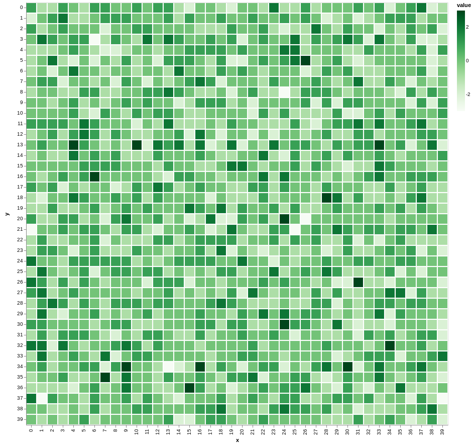

```python
N_loc = 0
N_std = 1

ter_shift = pd.DataFrame([[int(n) for n in np.round(np.random.normal(N_loc, N_std, len(oceanworld.columns)))]
              for r in oceanworld.index])

shiftedTerrainWorld = oceanworld.add(ter_shift)
draw.drawTerrainHeight(shiftedTerrainWorld)
```

# Mountains formed

Using Np.pad to build a pyramid, I'm making something that looks much more like a mountain. This is just a single mountain.

```python
def getMountain(height=2):
    a = [[height]]
    for i in range(height - 1, 0, -1):
        a = np.pad(a, ((1, 1), (1, 1)), 'constant', constant_values=i)
    return pd.DataFrame(a)

getMountain(height=4)
```

|  | 0 | 1 | 2 | 3 | 4 | 5 | 6 |
| --- | --- | --- | --- | --- | --- | --- | --- |
| 0 | 1 | 1 | 1 | 1 | 1 | 1 | 1 |
| 1 | 1 | 2 | 2 | 2 | 2 | 2 | 1 |
| 2 | 1 | 2 | 3 | 3 | 3 | 2 | 1 |
| 3 | 1 | 2 | 3 | 4 | 3 | 2 | 1 |
| 4 | 1 | 2 | 3 | 3 | 3 | 2 | 1 |
| 5 | 1 | 2 | 2 | 2 | 2 | 2 | 1 |
| 6 | 1 | 1 | 1 | 1 | 1 | 1 | 1 |

This is great, but I need to place the mountain on a random place on the terrain. Currently just drop the edges of the mountain if they go off the grid. I might wrap them around later.

```python
peak_height = 5

def get_random_chord(df):
    x = np.random.choice(df.index.tolist(),1)[0]
    y = np.random.choice(df.columns.tolist(),1)[0]
    coord = [x,y]
    return np.array(coord)

#pd.DataFrame(getMountain(height=peak_height))
c = get_random_chord(shiftedTerrainWorld)
m = getMountain(height=peak_height)

def reindexMountain(c,m):
    m.index = np.pad([c[1]],(round(len(m.index)/2)
                   ,round(len(m.index)/2)),
           'linear_ramp',
          end_values=(c[1]-round(len(m.index)/2),
                    c[1]+round(len(m.index)/2)
                     )
          )
    m.columns = np.pad([c[0]],(round(len(m.columns)/2)
                   ,round(len(m.columns)/2)),
           'linear_ramp',
          end_values=(c[0]-round(len(m.columns)/2),
                    c[0]+round(len(m.columns)/2)
                     )
          )
    return m

def truncateMountain(df,m):
    return df

print("Mountain Placed: ", c)

mdf = reindexMountain(c,m)
mdf
```

```
Mountain Placed:  [15 25]
```

|  | 11 | 12 | 13 | 14 | 15 | 16 | 17 | 18 | 19 |
| --- | --- | --- | --- | --- | --- | --- | --- | --- | --- |
| 21 | 1 | 1 | 1 | 1 | 1 | 1 | 1 | 1 | 1 |
| 22 | 1 | 2 | 2 | 2 | 2 | 2 | 2 | 2 | 1 |
| 23 | 1 | 2 | 3 | 3 | 3 | 3 | 3 | 2 | 1 |
| 24 | 1 | 2 | 3 | 4 | 4 | 4 | 3 | 2 | 1 |
| 25 | 1 | 2 | 3 | 4 | 5 | 4 | 3 | 2 | 1 |
| 26 | 1 | 2 | 3 | 4 | 4 | 4 | 3 | 2 | 1 |
| 27 | 1 | 2 | 3 | 3 | 3 | 3 | 3 | 2 | 1 |
| 28 | 1 | 2 | 2 | 2 | 2 | 2 | 2 | 2 | 1 |
| 29 | 1 | 1 | 1 | 1 | 1 | 1 | 1 | 1 | 1 |

This makes a much more *natural* looking mountain.

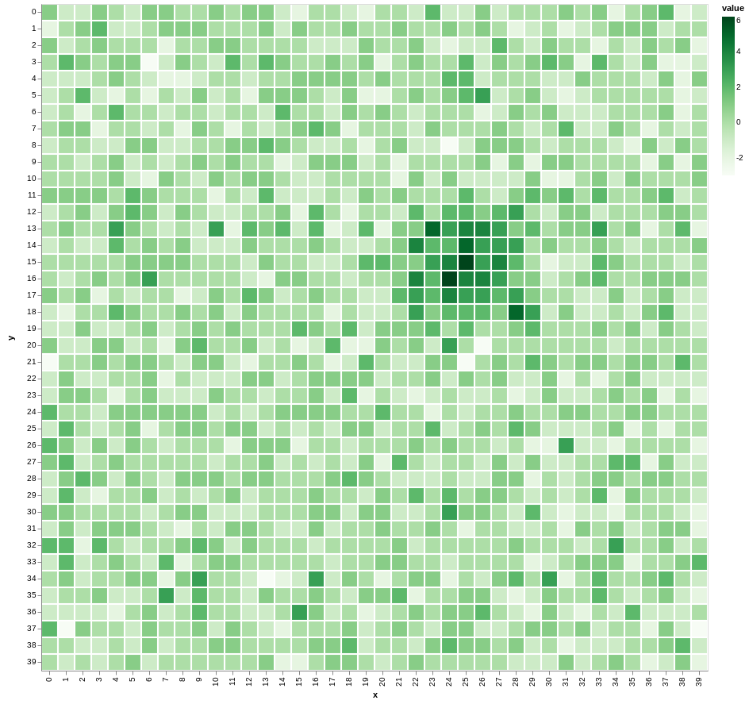

```python
mountainWorld = shiftedTerrainWorld.add(mdf.reindex_like(shiftedTerrainWorld).fillna(0))
draw.drawTerrainHeight(mountainWorld)
```

However, it's kind of blinded out by the overall randomness of the terrain.

```python
direction = [1,0,-1] #potential directions to move
def get_random_direction():
    return np.array([np.random.choice(direction),
            np.random.choice(direction)])

def get_next_coord(coord):
    nextcoord = np.add(coord,get_random_direction())
    return nextcoord

mt_avg = 2
mt_std = 1
def brownian_land(df,drop_iter,spread_iter):
    df_new = df.copy()
    for n in range(drop_iter):
        coord = get_random_chord(df_new)
        for m in range(spread_iter):
            try:
                coord = get_next_coord(coord)
                m = getMountain(height=abs(
                                        int(np.round(
                                            np.random.normal(2, 1))
                                              )))
                mdf = reindexMountain(coord,m)
                df_new = df_new.add(mdf.reindex_like(df_new).fillna(0))
            except:
                continue
    return df_new

#land Specifications
drop_iter = 5 #number of times a terain item will be dropped
spread_iter = 100 #number of times a dropped item will spread out (affects land mass size)


mountainLand = brownian_land(oceanworld,drop_iter,spread_iter)
```

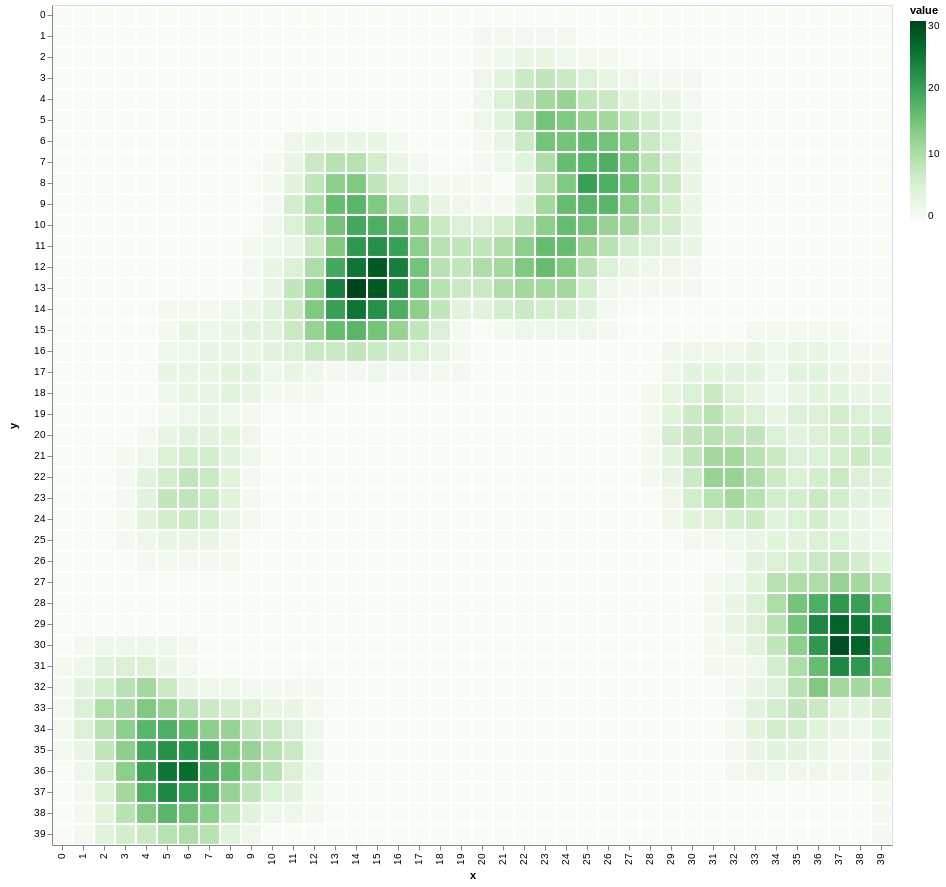

```python
draw.drawTerrainHeight(mountainLand)
```

Now that's starting to look like land. The shapes come out really map-like.

## Oceans

If the oceans were to come in at 0, then there would be some nice snakey continents. Yet they still don't really look like good continents with real *mountain ranges*

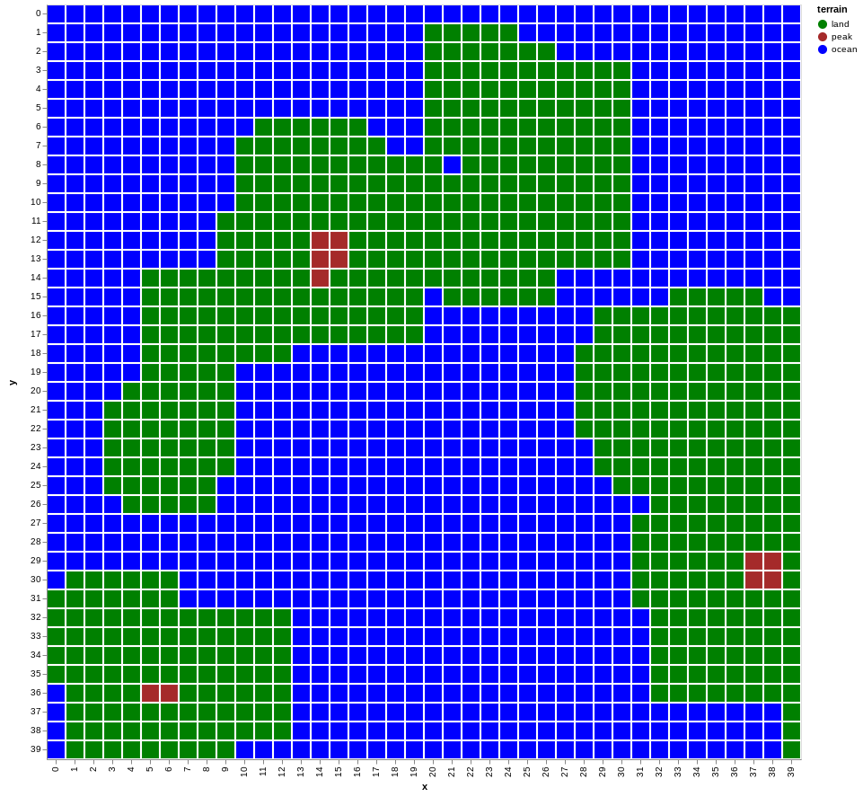

```python
landParams = {'water_level':0,
              'mountain_level':25}

draw.drawTerrainTypes(mountainLand,landParams)
```